# Descenso del Gradiente

Voy a realizar un descenso de gradiente en el lenguaje python utilizando las librerias basicas como ser pandas, numpy, matplotlib y seaborn.

El objetivo de este trabajo es comprender el funcionamiento interno de los algoritmos utilizados en Machine Learning.

## Autor: Hugo César Octavio del Sueldo

### Fecha: 05/11/2020

Lo primero que vamos a realizar sera la carga del fichero `4_1_data.csv` para poder trabajar sobre el mismo. Este fichero tiene la particularidad de ser simple para la implementacion del descenso de gradiente.

### Breve descripción y diccionario de variables del fichero

Suppose that you are an administrator of a university and you want to know the chance of admission of each applicant based on their two exams. You have historical data from previous applicants which can be used as the training data for logistic regression. Your task is to build a classification model that estimates each applicant’s probability of admission in university (Source:coursera machine learning class and Gondaliya (2013)).

Now, we have understood classification problem that we are going to address. Let us understand the data. In data we have records of previous applicants’ two exams score and label whether applicant got admission or not (1 - if got admission and 0 - otherwise).

NumPy is the only package that we will use in order to implement the logistic regression algorithm. All the others will only help us with small tasks such as visualizing the data at hand or creating a dataset. Hence, we won’t be using already implemented package solutions for logistic regression.

```python
import numpy as np
import pandas as pd
import seaborn as sns
from seaborn import lmplot
import matplotlib.pyplot as plt
%matplotlib inline
```

```python
data = pd.read_csv('./data/4_1_data.csv')
```

```python
data.head()
```

|  | score-1 | score-2 | label |
| --- | --- | --- | --- |
| 0 | 34.623660 | 78.024693 | 0 |
| 1 | 30.286711 | 43.894998 | 0 |
| 2 | 35.847409 | 72.902198 | 0 |
| 3 | 60.182599 | 86.308552 | 1 |
| 4 | 79.032736 | 75.344376 | 1 |

```python
data.tail()
```

|  | score-1 | score-2 | label |
| --- | --- | --- | --- |
| 95 | 83.489163 | 48.380286 | 1 |
| 96 | 42.261701 | 87.103851 | 1 |
| 97 | 99.315009 | 68.775409 | 1 |
| 98 | 55.340018 | 64.931938 | 1 |
| 99 | 74.775893 | 89.529813 | 1 |

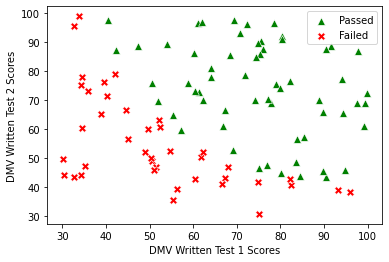

```python
scores = data[['score-1', 'score-2']].values #creamos scores con las notas
results = data['label'].values #creamos results con los resultados que pueden ser 0's o 1's

passed = (results == 1).reshape(100, 1) #creamos passed con los resultados que dieron 1. Que significa que pasaron el examen
failed = (results == 0).reshape(100, 1) #creamos failed con los resultados que dieron 0. Es decir, que no pasaron

#creamos un scatterplot con los objetos que hemos creado. Con los simbolos de triangulos o x dependiendo del resultado
ax = sns.scatterplot(x = scores[passed[:, 0], 0],
                     y = scores[passed[:, 0], 1],
                     marker = "^",
                     color = "green",
                     s = 60)
sns.scatterplot(x = scores[failed[:, 0], 0],
                y = scores[failed[:, 0], 1],
                marker = "X",
                color = "red",
                s = 60)

ax.set(xlabel="DMV Written Test 1 Scores", ylabel="DMV Written Test 2 Scores")
ax.legend(["Passed", "Failed"])
plt.show();
```

In this case we have two predictor variables (two exams’ scores) and label as response variable. This is binary classification, so we have only two classes (class 1 and class 0). The equation is the following:

$\hat{y} = \sigma(w_1x_1 + w_2*x_2 + b)$

Then, remember we want to find W and b that **minimizes the cost function** not the $\hat{y}$ function.

The objective of logistic regression is to minimize the cost function $$J(\theta) = -\frac{1}{m} \sum_{i=1}^{m} [ y^{(i)}log(h_{\theta}(x^{(i)})) + (1 - y^{(i)})log(1 - (h_{\theta}(x^{(i)}))]$$ where the gradient of the cost function is given by $$ \frac{\partial J(\theta)}{\partial \theta_j} = \frac{1}{m} \sum_{i=1}^{m} (h_{\theta}(x^{(i)}) - y^{(i)})x_j^{(i)}$$

Now we need to implement logistic regression so we can train a model to find the optimal decision boundary and make class predictions. The first step is to implement the sigmoid function.

```python
def sigmoid(x):
    return 1 / (1 + np.exp(-x))
```

This function is the “activation” function for the output of logistic regression. It converts a continuous input into a value between zero and one. This value can be interpreted as the class probability, or the likelihood that the input example should be classified positively. Using this probability along with a threshold value, we can obtain a discrete label prediction. It helps to visualize the function’s output to see what it’s really doing.

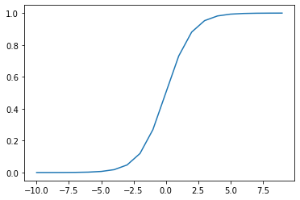

```python
x = np.arange(-10., 10., 1)
y = sigmoid(x)
plt.plot(x,y)
plt.show()
```

Our next step is to write the cost function. Remember that the cost function evaluates the performance of the model on the training data given a set of model parameters. Here’s the cost function for logistic regression.

```python
def compute_cost(theta, x, y): #la funcion de costo depende de los parametros theta
    m = len(y)  #m es el numero de observaciones
    y_pred = sigmoid(np.dot(x , theta))    #y hut = sigma(h^0 * x)
    error = (y * np.log(y_pred)) + ((1 - y) * np.log(1 - y_pred)) #error que es toda la formula
    cost = -1 / m * sum(error) #agregamos el costo que es -1/m por la sumatoria del error
    gradient = 1 / m * np.dot(x.transpose(), (y_pred - y)) #la funcion gradiente combina las dos funciones anteriores
    return cost[0] , gradient
```

Note that we reduce the output down to a single scalar value, which is the sum of the “error” quantified as a function of the difference between the class probability assigned by the model and the true label of the example. The implementation is completely vectorized — it’s computing the model’s predictions for the whole data set in one statement (sigmoid(X * theta)).

We can test the cost function to make sure it’s working, but first we need to do some setup.

```python
mean_scores = np.mean(scores, axis=0) #media de los resultados del examen
std_scores = np.std(scores, axis=0) #desviacion estandar de los resultados
scores = (scores - mean_scores) / std_scores #standardization o normalizamos

rows = scores.shape[0] #numeros de rows
cols = scores.shape[1] #numero de columns

X = np.append(np.ones((rows, 1)), scores, axis=1) #include intercept o termino independiente que tiene solo unos
y = results.reshape(rows, 1) #array con ceros y unos. Coloca los resultados de forma matriz

theta_init = np.zeros((cols + 1, 1)) #theta inicial. Son los parametros iniciales.
cost, gradient = compute_cost(theta_init, X, y) #costo con el theta inicial

print("Cost at initialization", cost) #imprimeme el costo inicial
print("Gradient at initialization:", gradient) #imprimeme los parametros del theta inicial
```

```
Cost at initialization 0.693147180559946
Gradient at initialization: [[-0.1       ]
 [-0.28122914]
 [-0.25098615]]
```

Now that we have a working cost function, the next step is to write a function that computes the gradient of the model parameters to figure out how to change the parameters to improve the outcome of the model on the training data. Recall that with gradient descent we don’t just randomly jigger around the parameter values and see what works best. At each training iteration we update the parameters in a way that’s guaranteed to move them in a direction that reduces the training error (i.e. the “cost”). We can do this because the cost function is differentiable.

Minimize the cost function $J(\theta)$ by updating the below equation and repeat until convergence $\theta_j := \theta_j - \alpha \frac{\partial J(\theta)}{\partial \theta_j}$ (simultaneously update $\theta_j$ for all $j$)

```python
def gradient_descent(x, y, theta, alpha, iterations): #gradient descent depende de x, y, theta, alpha, iteraciones
    costs = []
    for i in range(iterations): #iterame en la funcion costo y gradiente
        cost, gradient = compute_cost(theta, x, y) #minimiza el coste a medida que vamos bajando por el gradiente
        theta -= (alpha * gradient) #sustraemos del theta anterior la multipliacion de alpha * gradient. Alpha es la tasa de aprendizaje del algoritmo
        costs.append(cost)
    return theta, costs
```

```python
theta, costs = gradient_descent(X, y, theta_init, 0.75, 1000)
```

```python
print("Theta after running gradient descent:", theta)
print("Resulting cost:", costs[-1])
```

```
Theta after running gradient descent: [[1.71837638]
 [3.99263151]
 [3.72498545]]
Resulting cost: 0.20349770175210696
```

### Plot $J(\theta)$ against the number of iterations of gradient descent:

[figure not shown]

```python
plt.plot(costs)
plt.xlabel("Iterations")
plt.ylabel("$J(\Theta)$")
plt.title("Values of Cost Function over iterations of Gradient Descent");
```

After around 500 iterations the cost is flat so the remaining iterations are not needed or will not result in any further optimization. Let us zoom in till iteration 550 and see the curve

It is worth while to note that the cost drops faster initially and then the gain in cost reduction is not as much

```python
theta, costs = gradient_descent(X, y, theta_init, 0.75, 550)
```

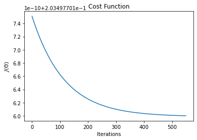

```python
plt.plot(costs)
plt.xlabel("Iterations")
plt.ylabel("$J(\Theta)$")
plt.title("Cost Function");
```

```python
theta, costs = gradient_descent(X, y, theta_init, 0.75, 300)
```

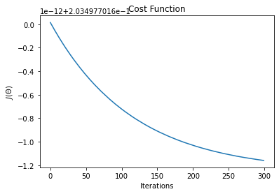

```python
plt.plot(costs)
plt.xlabel("Iterations")
plt.ylabel("$J(\Theta)$")
plt.title("Cost Function");
```

### Referencias

- https://towardsdatascience.com/logistic-regression-from-scratch-with-numpy-da4cc3121ece
- https://github.com/lmntrixsid/Linear-and-Logistic-Regression-with-NumPy-and-Python/blob/master/Logistic_Regression_Completed.ipynb
- https://towardsdatascience.com/gradient-descent-in-python-a0d07285742f
- https://towardsdatascience.com/implement-gradient-descent-in-python-9b93ed7108d1